# Practice Questions

# Question 1

## (a) Perform a simple linear regression with mpg as the response and horsepower as the pre- dictor. Comment on why you need to change the horsepower variable before performing the regression.

```r
lm( mpg ~ horsepower.numeric, auto)
```

```
Call:
lm(formula = mpg ~ horsepower.numeric, data = auto)

Coefficients:
       (Intercept)  horsepower.numeric
           39.9359             -0.1578
```

Horsepower was a factor variable, so we needed to convert it to a numeric.

## (b) Comment on the output by answering the following questions:

```r
summary(model1)
```

```
Call:
lm(formula = mpg ~ horsepower.numeric, data = auto)

Residuals:
     Min       1Q   Median       3Q      Max
-13.5710  -3.2592  -0.3435   2.7630  16.9240

Coefficients:
                    Estimate Std. Error t value Pr(>|t|)
(Intercept)        39.935861   0.717499   55.66   <2e-16 ***
horsepower.numeric -0.157845   0.006446  -24.49   <2e-16 ***
---
Signif. codes:  0 '***' 0.001 '**' 0.01 '*' 0.05 '.' 0.1 ' ' 1

Residual standard error: 4.906 on 390 degrees of freedom
  (5 observations deleted due to missingness)
Multiple R-squared:  0.6059,    Adjusted R-squared:  0.6049
F-statistic: 599.7 on 1 and 390 DF,  p-value: < 2.2e-16
```

### Is there a strong relationship between the predictor and the response?

It is quite strong as its p-value is almost 0, implying a strong relationship.

### Is the relationship between the predictor and the response positive or negative?

Negative

## (c) What is the predicted mpg associated with a horsepower of 98? What is the associated 99% confidence interval? Hint: You can check the predict.lm function on how the confidence interval can be computed for predictions with R.

```r
predict(model1, newdata = test, type = "response", interval = c("confidence"), level = .99)
```

```
       fit      lwr      upr
1 24.46708 23.81669 25.11747
```

# (d) Compute the correlation between the response and the predictor variable. How does this compare with the R2 value?

```r
cor(auto$mpg, auto$horsepower.numeric, use = "pairwise.complete.obs")
```

```
[1] -0.7784268
```

```r
cor(auto$mpg, auto$horsepower.numeric, use = "pairwise.complete.obs") ^ 2
```

```
[1] 0.6059483
```

## (e) Plot the response and the predictor. Also plot the least squares regression line.

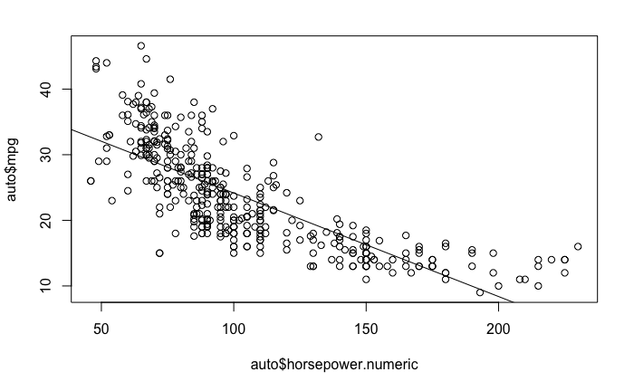

```r
plot(auto$horsepower.numeric, auto$mpg)
abline(model1)
```

## (f) Use the following two commands in R to produce diagnostic plots of the linear regression fit:

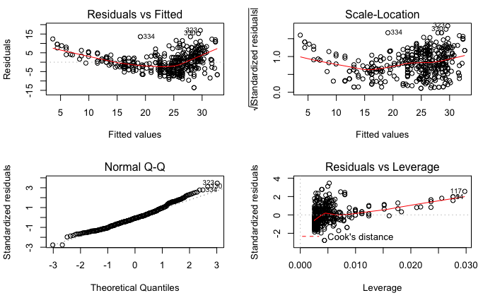

```r
layout(matrix(1:4,2,2))
plot(model1)
```

# Question 2

## (a) Produce a scatterplot matrix which includes all the variables in the dataset.

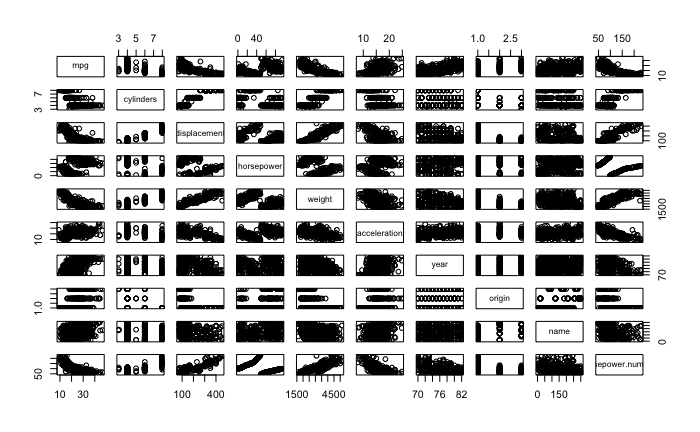

## (b) Compute a matrix of correlations between the variables using the function cor(). You need to exclude the name variables which is qualitative.

```r
cor(subset(auto, select = c(mpg, horsepower.numeric, displacement, weight, acceleration, year, origin)), use = "pairwise.complete.obs")
```

```
                          mpg horsepower.numeric displacement     weight acceleration       year
mpg                 1.0000000         -0.7784268   -0.8044430 -0.8317389    0.4222974  0.5814695
horsepower.numeric -0.7784268          1.0000000    0.8972570  0.8645377   -0.6891955 -0.4163615
displacement       -0.8044430          0.8972570    1.0000000  0.9331044   -0.5441618 -0.3698041
weight             -0.8317389          0.8645377    0.9331044  1.0000000   -0.4195023 -0.3079004
acceleration        0.4222974         -0.6891955   -0.5441618 -0.4195023    1.0000000  0.2829009
year                0.5814695         -0.4163615   -0.3698041 -0.3079004    0.2829009  1.0000000
origin              0.5636979         -0.4551715   -0.6106643 -0.5812652    0.2100836  0.1843141
                       origin
mpg                 0.5636979
horsepower.numeric -0.4551715
displacement       -0.6106643
weight             -0.5812652
acceleration        0.2100836
year                0.1843141
origin              1.0000000
```

### (c) Perform a multiple linear regression with mpg as the response and all other variables except name as the predictors. Comment on the output by answering the following questions:

```r
summary(model2)
```

```
Call:
lm(formula = mpg ~ horsepower.numeric + displacement + weight +
    acceleration + year + origin + cylinders, data = auto)

Residuals:
    Min      1Q  Median      3Q     Max
-9.5903 -2.1565 -0.1169  1.8690 13.0604

Coefficients:
                     Estimate Std. Error t value Pr(>|t|)
(Intercept)        -17.218435   4.644294  -3.707  0.00024 ***
horsepower.numeric  -0.016951   0.013787  -1.230  0.21963
displacement         0.019896   0.007515   2.647  0.00844 **
weight              -0.006474   0.000652  -9.929  < 2e-16 ***
acceleration         0.080576   0.098845   0.815  0.41548
year                 0.750773   0.050973  14.729  < 2e-16 ***
origin               1.426141   0.278136   5.127 4.67e-07 ***
cylinders           -0.493376   0.323282  -1.526  0.12780
---
Signif. codes:  0 '***' 0.001 '**' 0.01 '*' 0.05 '.' 0.1 ' ' 1

Residual standard error: 3.328 on 384 degrees of freedom
  (5 observations deleted due to missingness)
Multiple R-squared:  0.8215,    Adjusted R-squared:  0.8182
F-statistic: 252.4 on 7 and 384 DF,  p-value: < 2.2e-16
```

#### Is there a strong relationship between the predictors and the response?

Yes as the R^2 value is 0.8215, which is very high.

#### Which predictors appear to have a statistically significant relationship to the response?

There is a highly statistically significant between mpg and weight, year and origin. This can be seen from the very low p-values they have that allow us to reject the null hypothesis that they equal to 0. There is a slight relationship with displacement as well.

#### What does the coefficient for the year variable suggest?

There is a positive correlation between the year and the mpg. More recent cars have higher MPGs.